# Business Analytics_Project

Group-II

2023-11-16

```r
knitr::opts_chunk$set(echo = TRUE, comment = NULL)
knitr::opts_chunk$set(message = FALSE)
knitr::opts_chunk$set(warning = FALSE)
```

#Loading the required libraries.

```r
library(dplyr, warn.conflicts = FALSE)
library(caret, warn.conflicts = FALSE)
library(knitr, warn.conflicts = FALSE)
library(class, warn.conflicts = FALSE)
library(ggplot2, warn.conflicts = FALSE)
library(ggcorrplot, warn.conflicts = FALSE)
library(tidyr, warn.conflicts = FALSE)
library(corrplot, warn.conflicts = FALSE)
library(cowplot, warn.conflicts = FALSE)
library(pander, warn.conflicts = FALSE)
library(lattice, warn.conflicts = FALSE)
library(rpart, warn.conflicts = FALSE)
library(rpart.plot, warn.conflicts = FALSE)
library(rattle, warn.conflicts = FALSE)
library(logistf, warn.conflicts = FALSE)
library(tinytex, warn.conflicts = FALSE )
```

#Importing and reading dataset.

```r
library(readr)
library(readxl)
HP_train <- read.csv("C:/Users/spand/Downloads/House_Prices.csv")
HP_test <- read_excel("C:/Users/spand/Downloads/BA-Predict.xlsx")
```

#Displaying the first few rows of the datatset.

```r
head(HP_train)
```

```
  LotArea OverallQual YearBuilt YearRemodAdd BsmtFinSF1 FullBath HalfBath
1    8450           7      2003         2003        706        2        1
2    9600           6      1976         1976        978        2        0
3   11250           7      2001         2002        486        2        1
4    9550           7      1915         1970        216        1        0
5   14260           8      2000         2000        655        2        1
6   14115           5      1993         1995        732        1        1
  BedroomAbvGr TotRmsAbvGrd Fireplaces GarageArea YrSold SalePrice
1            3            8          0        548   2008    208500
2            3            6          1        460   2007    181500
3            3            6          1        608   2008    223500
4            3            7          1        642   2006    140000
5            4            9          1        836   2008    250000
6            1            5          0        480   2009    143000
```

```r
head(HP_test)
```

```
# A tibble: 6 × 13
  LotArea OverallQual YearBuilt YearRemodAdd BsmtFinSF1 FullBath HalfBath
    <dbl>       <dbl>     <dbl>        <dbl>      <dbl>    <dbl>    <dbl>
1    7340           4      1971         1971        322        1        0
2    8712           5      1957         2000        860        1        0
3    7875           7      2003         2003          0        2        1
4   14859           7      2006         2006          0        2        0
5    6173           5      1967         1967        599        1        0
6    9920           5      1954         1954        354        1        0
# ℹ 6 more variables: BedroomAbvGr <dbl>, TotRmsAbvGrd <dbl>, Fireplaces <dbl>,
#   GarageArea <dbl>, YrSold <dbl>, SalePrice <dbl>
```

#Displaying the shape of the dataset.

```r
dim(HP_train)
```

```
[1] 900  13
```

```r
dim(HP_test)
```

```
[1] 90 13
```

#### Descriptive Analysis:-

Descriptive statistics refers to the branch of statistics that involves methods for summarizing and presenting data in a meaningful and informative way, helping to uncover key characteristics and patterns within a dataset.

#Understanding the structure of the dataset.

```r
str(HP_train)
```

```
'data.frame':   900 obs. of  13 variables:
 $ LotArea     : int  8450 9600 11250 9550 14260 14115 10084 10382 6120 7420 ...
 $ OverallQual : int  7 6 7 7 8 5 8 7 7 5 ...
 $ YearBuilt   : int  2003 1976 2001 1915 2000 1993 2004 1973 1931 1939 ...
 $ YearRemodAdd: int  2003 1976 2002 1970 2000 1995 2005 1973 1950 1950 ...
 $ BsmtFinSF1  : int  706 978 486 216 655 732 1369 859 0 851 ...
 $ FullBath    : int  2 2 2 1 2 1 2 2 2 1 ...
 $ HalfBath    : int  1 0 1 0 1 1 0 1 0 0 ...
 $ BedroomAbvGr: int  3 3 3 3 4 1 3 3 2 2 ...
 $ TotRmsAbvGrd: int  8 6 6 7 9 5 7 7 8 5 ...
 $ Fireplaces  : int  0 1 1 1 1 0 1 2 2 2 ...
 $ GarageArea  : int  548 460 608 642 836 480 636 484 468 205 ...
 $ YrSold      : int  2008 2007 2008 2006 2008 2009 2007 2009 2008 2008 ...
 $ SalePrice   : int  208500 181500 223500 140000 250000 143000 307000 200000 129900 118000 ...
```

```r
str(HP_test)
```

```
tibble [90 × 13] (S3: tbl_df/tbl/data.frame)
 $ LotArea     : num [1:90] 7340 8712 7875 14859 6173 ...
 $ OverallQual : num [1:90] 4 5 7 7 5 5 8 7 5 6 ...
 $ YearBuilt   : num [1:90] 1971 1957 2003 2006 1967 ...
 $ YearRemodAdd: num [1:90] 1971 2000 2003 2006 1967 ...
 $ BsmtFinSF1  : num [1:90] 322 860 0 0 599 354 63 223 301 0 ...
 $ FullBath    : num [1:90] 1 1 2 2 1 1 2 1 1 2 ...
 $ HalfBath    : num [1:90] 0 0 1 0 0 0 0 1 0 1 ...
 $ BedroomAbvGr: num [1:90] 2 2 3 3 3 3 3 3 2 3 ...
 $ TotRmsAbvGrd: num [1:90] 4 5 8 7 6 6 8 6 5 8 ...
 $ Fireplaces  : num [1:90] 0 0 1 1 0 0 1 1 0 1 ...
 $ GarageArea  : num [1:90] 684 756 393 690 288 280 865 180 484 390 ...
 $ YrSold      : num [1:90] 2007 2009 2006 2006 2007 ...
 $ SalePrice   : num [1:90] 110000 153000 180000 240000 125500 ...
```

#Understanding the summary of the dataset.

```r
summary(HP_train)
```

```
    LotArea        OverallQual       YearBuilt     YearRemodAdd
 Min.   :  1491   Min.   : 1.000   Min.   :1880   Min.   :1950
 1st Qu.:  7585   1st Qu.: 5.000   1st Qu.:1954   1st Qu.:1968
 Median :  9442   Median : 6.000   Median :1973   Median :1994
 Mean   : 10795   Mean   : 6.136   Mean   :1971   Mean   :1985
 3rd Qu.: 11618   3rd Qu.: 7.000   3rd Qu.:2000   3rd Qu.:2004
 Max.   :215245   Max.   :10.000   Max.   :2010   Max.   :2010
   BsmtFinSF1        FullBath        HalfBath       BedroomAbvGr
 Min.   :   0.0   Min.   :0.000   Min.   :0.0000   Min.   :0.000
 1st Qu.:   0.0   1st Qu.:1.000   1st Qu.:0.0000   1st Qu.:2.000
 Median : 384.0   Median :2.000   Median :0.0000   Median :3.000
 Mean   : 446.5   Mean   :1.564   Mean   :0.3856   Mean   :2.843
 3rd Qu.: 728.8   3rd Qu.:2.000   3rd Qu.:1.0000   3rd Qu.:3.000
 Max.   :2260.0   Max.   :3.000   Max.   :2.0000   Max.   :8.000
  TotRmsAbvGrd      Fireplaces       GarageArea         YrSold
 Min.   : 2.000   Min.   :0.0000   Min.   :   0.0   Min.   :2006
 1st Qu.: 5.000   1st Qu.:0.0000   1st Qu.: 336.0   1st Qu.:2007
 Median : 6.000   Median :1.0000   Median : 480.0   Median :2008
 Mean   : 6.482   Mean   :0.6278   Mean   : 472.6   Mean   :2008
 3rd Qu.: 7.000   3rd Qu.:1.0000   3rd Qu.: 576.0   3rd Qu.:2009
 Max.   :14.000   Max.   :3.0000   Max.   :1390.0   Max.   :2010
   SalePrice
 Min.   : 34900
 1st Qu.:130000
 Median :163000
 Mean   :183108
 3rd Qu.:216878
 Max.   :755000
```

```r
summary(HP_test)
```

```
    LotArea       OverallQual   YearBuilt     YearRemodAdd    BsmtFinSF1
 Min.   : 1300   Min.   :2    Min.   :1890   Min.   :1950   Min.   :   0.0
 1st Qu.: 7493   1st Qu.:5    1st Qu.:1958   1st Qu.:1966   1st Qu.:   0.0
 Median : 9380   Median :6    Median :1976   Median :1994   Median : 407.5
 Mean   : 9713   Mean   :6    Mean   :1974   Mean   :1985   Mean   : 426.1
 3rd Qu.:11629   3rd Qu.:7    3rd Qu.:2002   3rd Qu.:2004   3rd Qu.: 687.0
 Max.   :27650   Max.   :9    Max.   :2009   Max.   :2010   Max.   :1646.0
    FullBath        HalfBath       BedroomAbvGr    TotRmsAbvGrd
 Min.   :0.000   Min.   :0.0000   Min.   :1.000   Min.   : 4.000
 1st Qu.:1.000   1st Qu.:0.0000   1st Qu.:2.250   1st Qu.: 5.250
 Median :2.000   Median :0.0000   Median :3.000   Median : 6.000
 Mean   :1.578   Mean   :0.3778   Mean   :2.967   Mean   : 6.633
 3rd Qu.:2.000   3rd Qu.:1.0000   3rd Qu.:3.000   3rd Qu.: 8.000
 Max.   :2.000   Max.   :2.0000   Max.   :5.000   Max.   :12.000
   Fireplaces       GarageArea        YrSold       SalePrice
 Min.   :0.0000   Min.   :  0.0   Min.   :2006   Min.   : 35311
 1st Qu.:0.0000   1st Qu.:388.5   1st Qu.:2007   1st Qu.:132475
 Median :0.0000   Median :491.0   Median :2008   Median :166250
 Mean   :0.4333   Mean   :475.4   Mean   :2008   Mean   :172587
 3rd Qu.:1.0000   3rd Qu.:604.8   3rd Qu.:2009   3rd Qu.:200725
 Max.   :2.0000   Max.   :871.0   Max.   :2010   Max.   :395192
```

##### Data Preparation:-

Data preparation is the process of cleaning and organizing raw data to make it suitable for analysis. It involves handling missing values, removing duplicates, and transforming variables. The goal is to ensure data quality and usability for modeling and analysis tasks.

#Checking if there are any missing values column wise and plotting a graph for it.

```r
Missing_HP_train = colSums(is.na(HP_train))
Missing_HP_test = colSums(is.na(HP_test))
print(Missing_HP_train)
```

```
     LotArea  OverallQual    YearBuilt YearRemodAdd   BsmtFinSF1     FullBath
           0            0            0            0            0            0
    HalfBath BedroomAbvGr TotRmsAbvGrd   Fireplaces   GarageArea       YrSold
           0            0            0            0            0            0
   SalePrice
           0
```

```r
print(Missing_HP_test)
```

```
     LotArea  OverallQual    YearBuilt YearRemodAdd   BsmtFinSF1     FullBath
           0            0            0            0            0            0
    HalfBath BedroomAbvGr TotRmsAbvGrd   Fireplaces   GarageArea       YrSold
           0            0            0            0            0            0
   SalePrice
           0
```

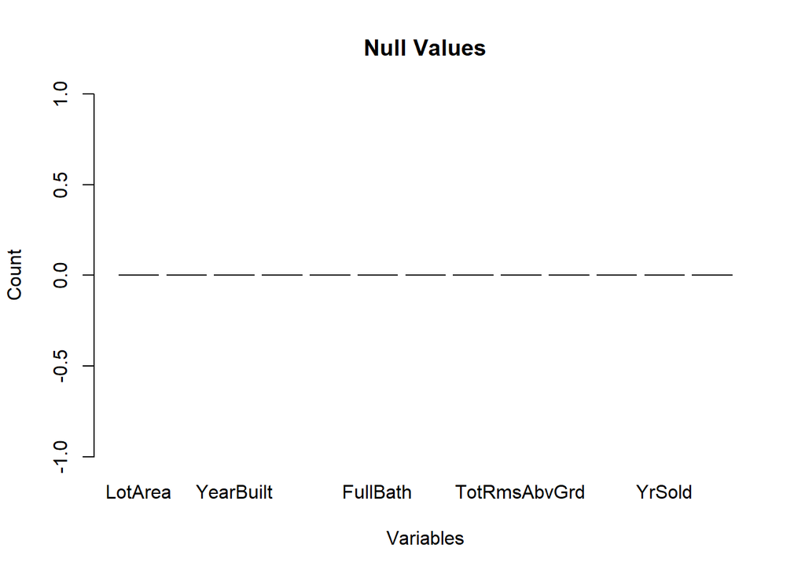

```r
Plot_HP_train <- barplot(Missing_HP_train, main = "Null Values", xlab = "Variables", ylab = "Count")
Plot_HP_test <- barplot(Missing_HP_test, main = "Null Values", xlab = "Variables", ylab = "Count")
```

[output not shown]

The dataset, both in the training and test sets, does not contain any missing values across various property features, ensuring a complete and reliable dataset for analysis and model development.

#### Data Exploration:-

Data Exploration refers to a set of techniques used to gain a better understanding of the data. It is a combination of both descriptive and visualization. It helps in selecting the right tool for analyzing the data and making use of human abilities to recognize patterns in the data. Descriptive analysis has been covered so moving on data visualization.

#### Data Visualization:-

Data visualization is the process of presenting information graphically, utilizing charts, graphs, and visual elements to convey complex data patterns and trends in a concise and understandable manner. It involves translating large datasets into visual representations that facilitate easier interpretation and analysis.

#Creating the histograms for all the numerical variables.

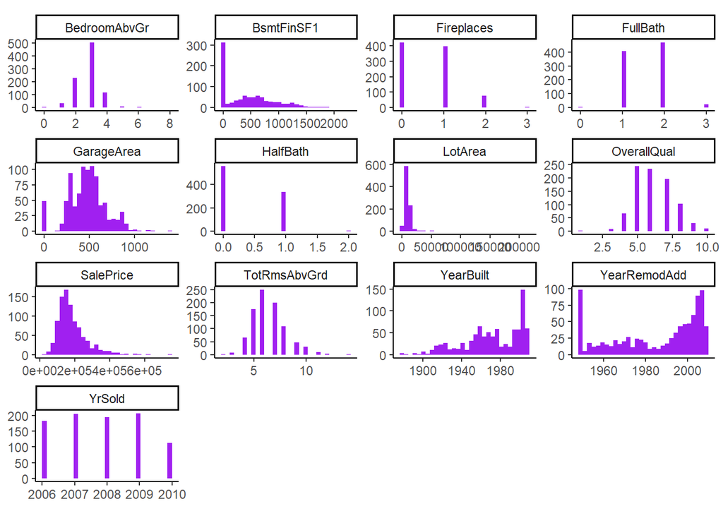

```r
Hist_data <- HP_train %>%
  gather(key = "Variable", value = "Value")

ggplot(Hist_data, aes(x = Value)) +
  geom_histogram(fill = "purple", bins = 30) +
  facet_wrap(~ Variable, scales = 'free') +
  theme_classic() +
  theme(aspect.ratio = 0.5, axis.title = element_blank(), panel.grid = element_blank())
```

#Using Pairs function to show the scatter plots for every pair or variables.

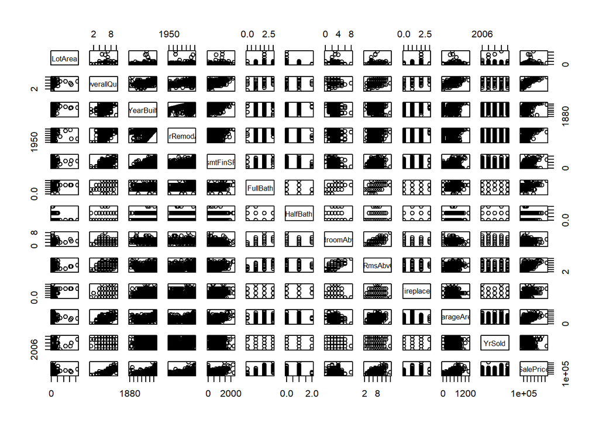

```r
pairs(HP_train)
```

Pairs visually display the scatter plots for each pair of variables in a dataset, facilitating the examination of relationships and patterns. In the context of SalePrice as the response variable, commonalities among variables like LotArea, OverallQual, YearRemodAdd, BsmtFinSF1, BedroomAbvGr, TotRmsAbvGrd, Fireplaces, GarageArea can be observed.

#Correlation Analysis: Creating a correlation Heat map.

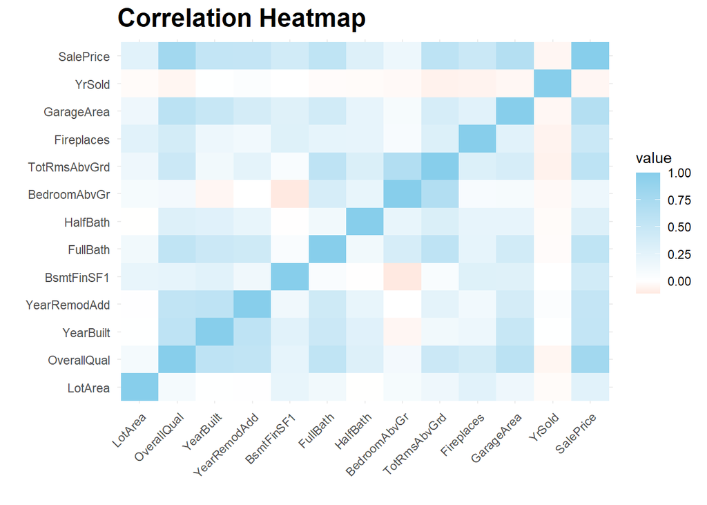

```r
cor_matrix <- cor(HP_train)
cor_df <- reshape2::melt(cor_matrix)
ggplot(cor_df, aes(Var1, Var2, fill = value)) +
  geom_tile() +
  scale_fill_gradient2(low = "red", mid = "white", high = "skyblue", midpoint = 0, na.value = "grey5") +
  labs(title = "Correlation Heatmap", x = "", y = "") +
  theme_minimal() +
  theme(axis.text.x = element_text(angle = 45, hjust = 1),
        plot.title = element_text(size = 18, face = "bold"))
```

The above correlation plot is a statistical measure that quantifies the degree to which the output variable changes basing on the independent variable. It indicates the direction and strength of the linear relationship between them. The correlation coefficient, typically ranging from -1 to 1, helps assess whether an increase in one variable corresponds to an increase, decrease, or no change in the response which is the SalePrice.

#### Feature Selection:-

#Compute correlation matrix.

```r
cor_matrix <- cor(HP_train)
print(cor_matrix)
```

```
                  LotArea OverallQual    YearBuilt YearRemodAdd    BsmtFinSF1
LotArea       1.000000000  0.09620900  0.007639049  0.012302233  0.2070351970
OverallQual   0.096209000  1.00000000  0.569224830  0.547469449  0.2273585019
YearBuilt     0.007639049  0.56922483  1.000000000  0.569603899  0.2645981421
YearRemodAdd  0.012302233  0.54746945  0.569603899  1.000000000  0.1322065658
BsmtFinSF1    0.207035197  0.22735850  0.264598142  0.132206566  1.0000000000
FullBath      0.128546736  0.55070872  0.462667254  0.434997143  0.0528409217
HalfBath     -0.002609033  0.30428590  0.275348758  0.205962493 -0.0030280922
BedroomAbvGr  0.089577976  0.11259055 -0.046072471  0.004014058 -0.1160040411
TotRmsAbvGrd  0.153195236  0.45870224  0.128529938  0.238986430  0.0592866707
Fireplaces    0.265591816  0.39348553  0.164903221  0.122247285  0.2929777189
GarageArea    0.152719594  0.59816621  0.496030798  0.379742202  0.2869557945
YrSold       -0.021080234 -0.04878042  0.008917924  0.036269555 -0.0007843919
SalePrice     0.264372456  0.79621347  0.526634079  0.522177319  0.4046632164
                FullBath     HalfBath BedroomAbvGr TotRmsAbvGrd Fireplaces
LotArea       0.12854674 -0.002609033  0.089577976   0.15319524  0.2655918
OverallQual   0.55070872  0.304285902  0.112590545   0.45870224  0.3934855
YearBuilt     0.46266725  0.275348758 -0.046072471   0.12852994  0.1649032
YearRemodAdd  0.43499714  0.205962493  0.004014058   0.23898643  0.1222473
BsmtFinSF1    0.05284092 -0.003028092 -0.116004041   0.05928667  0.2929777
FullBath      1.00000000  0.129184827  0.364023796   0.56631807  0.2252192
HalfBath      0.12918483  1.000000000  0.203046332   0.33171413  0.2173755
BedroomAbvGr  0.36402380  0.203046332  1.000000000   0.67145361  0.0754022
TotRmsAbvGrd  0.56631807  0.331714132  0.671453609   1.00000000  0.3103836
Fireplaces    0.22521918  0.217375465  0.075402205   0.31038357  1.0000000
GarageArea    0.41050735  0.218421176  0.081228219   0.36196401  0.2662601
YrSold       -0.02033726 -0.023043594 -0.028929972  -0.06891411 -0.0619571
SalePrice     0.55801287  0.304740001  0.164426978   0.57735815  0.4686277
              GarageArea        YrSold   SalePrice
LotArea       0.15271959 -0.0210802344  0.26437246
OverallQual   0.59816621 -0.0487804195  0.79621347
YearBuilt     0.49603080  0.0089179239  0.52663408
YearRemodAdd  0.37974220  0.0362695545  0.52217732
BsmtFinSF1    0.28695579 -0.0007843919  0.40466322
FullBath      0.41050735 -0.0203372558  0.55801287
HalfBath      0.21842118 -0.0230435945  0.30474000
BedroomAbvGr  0.08122822 -0.0289299716  0.16442698
TotRmsAbvGrd  0.36196401 -0.0689141092  0.57735815
Fireplaces    0.26626008 -0.0619571010  0.46862767
GarageArea    1.00000000 -0.0438451173  0.65604203
YrSold       -0.04384512  1.0000000000 -0.04627185
SalePrice     0.65604203 -0.0462718468  1.00000000
```

#Creating correlation heatmap.

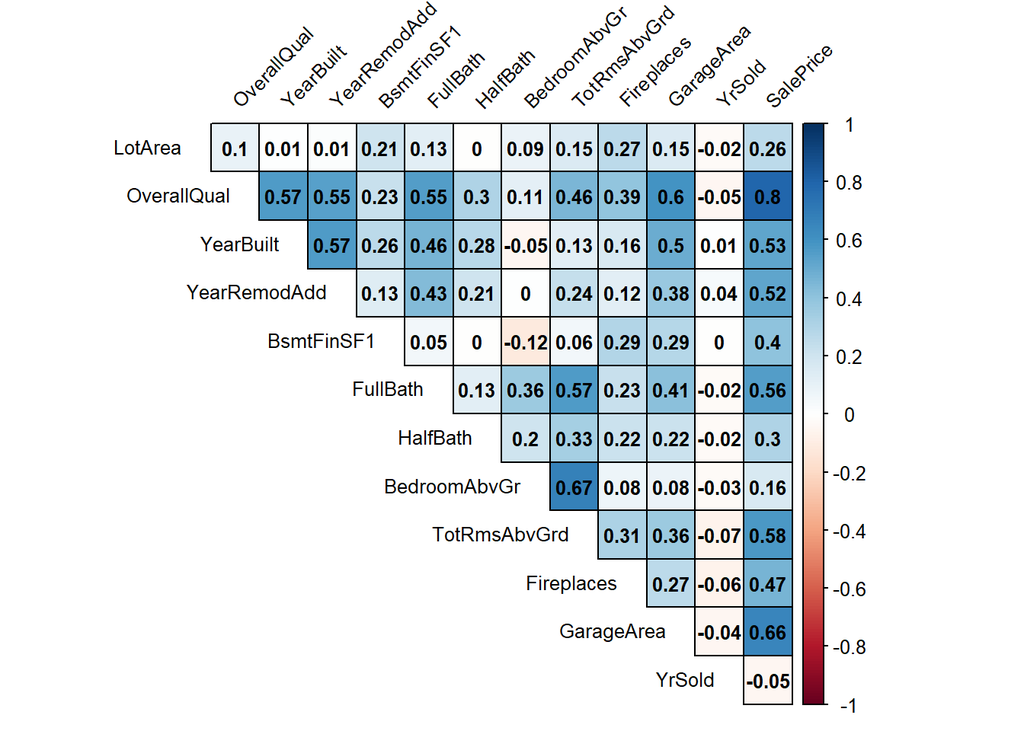

```r
corrplot(cor_matrix, method = "color", type = "upper", tl.col = "black",
tl.srt = 45, tl.cex = 0.8, tl.offset = 1,
addCoef.col = "black", number.cex = 0.8, number.digits = 2,
diag = FALSE, outline = TRUE)
```

#Using Step-wise Regression to determine the importance of the features.

```r
Model <- lm(SalePrice ~ ., data = HP_train)
Step_Model <- step(Model)
```

```
Start:  AIC=18910.41
SalePrice ~ LotArea + OverallQual + YearBuilt + YearRemodAdd +
    BsmtFinSF1 + FullBath + HalfBath + BedroomAbvGr + TotRmsAbvGrd +
    Fireplaces + GarageArea + YrSold

               Df  Sum of Sq        RSS   AIC
- YrSold        1 2.6365e+07 1.1666e+12 18908
- HalfBath      1 1.5739e+09 1.1681e+12 18910
<none>                       1.1665e+12 18910
- FullBath      1 4.3480e+09 1.1709e+12 18912
- YearBuilt     1 5.9547e+09 1.1725e+12 18913
- Fireplaces    1 2.5641e+10 1.1922e+12 18928
- YearRemodAdd  1 3.1832e+10 1.1984e+12 18933
- BedroomAbvGr  1 3.6445e+10 1.2030e+12 18936
- LotArea       1 5.7047e+10 1.2236e+12 18951
- GarageArea    1 8.2303e+10 1.2489e+12 18970
- BsmtFinSF1    1 1.3424e+11 1.3008e+12 19006
- TotRmsAbvGrd  1 1.8450e+11 1.3511e+12 19041
- OverallQual   1 3.4552e+11 1.5121e+12 19142

Step:  AIC=18908.43
SalePrice ~ LotArea + OverallQual + YearBuilt + YearRemodAdd +
    BsmtFinSF1 + FullBath + HalfBath + BedroomAbvGr + TotRmsAbvGrd +
    Fireplaces + GarageArea

               Df  Sum of Sq        RSS   AIC
- HalfBath      1 1.5762e+09 1.1681e+12 18908
<none>                       1.1666e+12 18908
- FullBath      1 4.3596e+09 1.1709e+12 18910
- YearBuilt     1 5.9571e+09 1.1725e+12 18911
- Fireplaces    1 2.5615e+10 1.1922e+12 18926
- YearRemodAdd  1 3.2070e+10 1.1986e+12 18931
- BedroomAbvGr  1 3.6421e+10 1.2030e+12 18934
- LotArea       1 5.7043e+10 1.2236e+12 18949
- GarageArea    1 8.2278e+10 1.2489e+12 18968
- BsmtFinSF1    1 1.3438e+11 1.3010e+12 19005
- TotRmsAbvGrd  1 1.8468e+11 1.3513e+12 19039
- OverallQual   1 3.4569e+11 1.5123e+12 19140

Step:  AIC=18907.64
SalePrice ~ LotArea + OverallQual + YearBuilt + YearRemodAdd +
    BsmtFinSF1 + FullBath + BedroomAbvGr + TotRmsAbvGrd + Fireplaces +
    GarageArea

               Df  Sum of Sq        RSS   AIC
<none>                       1.1681e+12 18908
- FullBath      1 3.3360e+09 1.1715e+12 18908
- YearBuilt     1 8.1358e+09 1.1763e+12 18912
- Fireplaces    1 2.7748e+10 1.1959e+12 18927
- YearRemodAdd  1 3.2408e+10 1.2006e+12 18930
- BedroomAbvGr  1 3.5723e+10 1.2039e+12 18933
- LotArea       1 5.6363e+10 1.2245e+12 18948
- GarageArea    1 8.2260e+10 1.2504e+12 18967
- BsmtFinSF1    1 1.3300e+11 1.3011e+12 19003
- TotRmsAbvGrd  1 2.0316e+11 1.3713e+12 19050
- OverallQual   1 3.5067e+11 1.5188e+12 19142
```

```r
summary(Step_Model)
```

```
Call:
lm(formula = SalePrice ~ LotArea + OverallQual + YearBuilt +
    YearRemodAdd + BsmtFinSF1 + FullBath + BedroomAbvGr + TotRmsAbvGrd +
    Fireplaces + GarageArea, data = HP_train)

Residuals:
    Min      1Q  Median      3Q     Max
-284907  -20317   -2692   16283  350668

Coefficients:
               Estimate Std. Error t value Pr(>|t|)
(Intercept)  -1.155e+06  1.572e+05  -7.345 4.67e-13 ***
LotArea       7.060e-01  1.078e-01   6.549 9.76e-11 ***
OverallQual   2.309e+04  1.413e+03  16.336  < 2e-16 ***
YearBuilt     1.464e+02  5.883e+01   2.488    0.013 *
YearRemodAdd  3.881e+02  7.816e+01   4.966 8.19e-07 ***
BsmtFinSF1    3.053e+01  3.035e+00  10.061  < 2e-16 ***
FullBath      4.979e+03  3.125e+03   1.593    0.111
BedroomAbvGr -1.122e+04  2.152e+03  -5.214 2.30e-07 ***
TotRmsAbvGrd  1.618e+04  1.301e+03  12.434  < 2e-16 ***
Fireplaces    9.879e+03  2.150e+03   4.595 4.94e-06 ***
GarageArea    6.103e+01  7.713e+00   7.912 7.50e-15 ***
---
Signif. codes:  0 '***' 0.001 '**' 0.01 '*' 0.05 '.' 0.1 ' ' 1

Residual standard error: 36250 on 889 degrees of freedom
Multiple R-squared:  0.8063,    Adjusted R-squared:  0.8041
F-statistic: 370.1 on 10 and 889 DF,  p-value: < 2.2e-16
```

#Applying the linear regression model with the variables that are determined significant in the step-wise regression method.

```r
Model_1 <- lm(SalePrice ~ LotArea + OverallQual + YearRemodAdd + BsmtFinSF1 + BedroomAbvGr +  TotRmsAbvGrd + Fireplaces + GarageArea, data = HP_train)
summary(Model_1)
```

```
Call:
lm(formula = SalePrice ~ LotArea + OverallQual + YearRemodAdd +
    BsmtFinSF1 + BedroomAbvGr + TotRmsAbvGrd + Fireplaces + GarageArea,
    data = HP_train)

Residuals:
    Min      1Q  Median      3Q     Max
-284015  -19879   -2606   17052  351097

Coefficients:
               Estimate Std. Error t value Pr(>|t|)
(Intercept)  -1.075e+06  1.407e+05  -7.640 5.61e-14 ***
LotArea       6.986e-01  1.077e-01   6.487 1.45e-10 ***
OverallQual   2.466e+04  1.345e+03  18.335  < 2e-16 ***
YearRemodAdd  4.903e+02  7.254e+01   6.759 2.52e-11 ***
BsmtFinSF1    3.130e+01  2.993e+00  10.457  < 2e-16 ***
BedroomAbvGr -1.044e+04  2.148e+03  -4.862 1.37e-06 ***
TotRmsAbvGrd  1.607e+04  1.230e+03  13.063  < 2e-16 ***
Fireplaces    9.655e+03  2.161e+03   4.468 8.91e-06 ***
GarageArea    6.675e+01  7.538e+00   8.855  < 2e-16 ***
---
Signif. codes:  0 '***' 0.001 '**' 0.01 '*' 0.05 '.' 0.1 ' ' 1

Residual standard error: 36450 on 891 degrees of freedom
Multiple R-squared:  0.8037,    Adjusted R-squared:  0.802
F-statistic: 456.1 on 8 and 891 DF,  p-value: < 2.2e-16
```

#Using the anova analysis and to determine the importance of the variables.

```r
anova(Model_1)
```

```
Analysis of Variance Table

Response: SalePrice
              Df     Sum Sq    Mean Sq  F value    Pr(>F)
LotArea        1 4.2155e+11 4.2155e+11  317.273 < 2.2e-16 ***
OverallQual    1 3.6167e+12 3.6167e+12 2722.061 < 2.2e-16 ***
YearRemodAdd   1 7.6161e+10 7.6161e+10   57.322 9.240e-14 ***
BsmtFinSF1     1 2.2966e+11 2.2966e+11  172.850 < 2.2e-16 ***
BedroomAbvGr   1 6.2001e+10 6.2001e+10   46.664 1.560e-11 ***
TotRmsAbvGrd   1 3.1449e+11 3.1449e+11  236.697 < 2.2e-16 ***
Fireplaces     1 2.2765e+10 2.2765e+10   17.134 3.814e-05 ***
GarageArea     1 1.0419e+11 1.0419e+11   78.418 < 2.2e-16 ***
Residuals    891 1.1838e+12 1.3287e+09
---
Signif. codes:  0 '***' 0.001 '**' 0.01 '*' 0.05 '.' 0.1 ' ' 1
```

Interpretation:- By examining the correlation matrix, correlation heatmap, and by looking at the P-values in linear regression model and ANOVA analysis, we can determine that LotArea, OverallQual, YearRemodAdd, BsmtFinSF1, BedroomAbvGr, TotRmsAbvGrd, Fireplaces, GarageArea are the features that have influence on the target variable.

##### Predictive Analysis:-

Predictive analysis involves using statistical algorithms and machine learning techniques to analyze historical data and make predictions about future outcomes. It aims to identify patterns and trends in the data to make informed forecasts, enabling better decision-making and planning. We will now implement various models such as Regression, Decision Tree, and Logistic Regression models on the House Prices dataset for Prediction.

#Splitting the data into training and test set.

```r
set.seed(1)
train.index <- sample(row.names(HP_train))
test.index <- sample(row.names(HP_test))
```

#### Regression Model:-

Following the execution of the linear regression model with the chosen features namely LotArea, OverallQual, YearRemodAdd, BsmtFinSF1, BedroomAbvGr, TotRmsAbvGrd, Fireplaces, GarageArea and proceed to re-run the linear model.

#Predicting the price of a house based on selected predictors.

```r
Model_2 <- lm(SalePrice ~ LotArea + OverallQual + YearRemodAdd + BsmtFinSF1 + BedroomAbvGr +  TotRmsAbvGrd + Fireplaces + GarageArea, data = HP_train)
summary(Model_2)
```

```
Call:
lm(formula = SalePrice ~ LotArea + OverallQual + YearRemodAdd +
    BsmtFinSF1 + BedroomAbvGr + TotRmsAbvGrd + Fireplaces + GarageArea,
    data = HP_train)

Residuals:
    Min      1Q  Median      3Q     Max
-284015  -19879   -2606   17052  351097

Coefficients:
               Estimate Std. Error t value Pr(>|t|)
(Intercept)  -1.075e+06  1.407e+05  -7.640 5.61e-14 ***
LotArea       6.986e-01  1.077e-01   6.487 1.45e-10 ***
OverallQual   2.466e+04  1.345e+03  18.335  < 2e-16 ***
YearRemodAdd  4.903e+02  7.254e+01   6.759 2.52e-11 ***
BsmtFinSF1    3.130e+01  2.993e+00  10.457  < 2e-16 ***
BedroomAbvGr -1.044e+04  2.148e+03  -4.862 1.37e-06 ***
TotRmsAbvGrd  1.607e+04  1.230e+03  13.063  < 2e-16 ***
Fireplaces    9.655e+03  2.161e+03   4.468 8.91e-06 ***
GarageArea    6.675e+01  7.538e+00   8.855  < 2e-16 ***
---
Signif. codes:  0 '***' 0.001 '**' 0.01 '*' 0.05 '.' 0.1 ' ' 1

Residual standard error: 36450 on 891 degrees of freedom
Multiple R-squared:  0.8037,    Adjusted R-squared:  0.802
F-statistic: 456.1 on 8 and 891 DF,  p-value: < 2.2e-16
```

```r
Predicted_value_1 <- predict(Model_2, data.frame(HP_test))
Predicted_value_1
```

```
        1         2         3         4         5         6         7         8
 94075.22 171627.24 218101.94 228209.70 119889.17 107930.68 281644.41 173420.57
        9        10        11        12        13        14        15        16
127760.91 197511.00 203689.64 101766.04 118887.99 162365.27 147712.39  74898.47
       17        18        19        20        21        22        23        24
 12443.90 111624.78 236313.95 193429.05 194400.16 173068.94 165569.61 165876.39
       25        26        27        28        29        30        31        32
201928.85 153464.02 285380.26 231465.28 237098.55 224920.92 234725.31 116573.49
       33        34        35        36        37        38        39        40
297917.98 189673.43 260277.80  90211.01 209122.67 250771.08 240699.50 231851.38
       41        42        43        44        45        46        47        48
204809.92 240719.76 129990.40 155203.48 172136.02 188985.99 165583.95 331877.43
       49        50        51        52        53        54        55        56
211235.11 197374.80 144243.26 122160.86 141752.08 154565.51  99759.76 168596.96
       57        58        59        60        61        62        63        64
153341.00 131835.84 207807.49 195629.51 102836.49 273440.83 180786.26 277568.19
       65        66        67        68        69        70        71        72
237402.85 197048.72 152279.87 122471.51  34524.47 149231.83  41705.75 206487.05
       73        74        75        76        77        78        79        80
135318.72 187202.95 215295.16 197733.58  30961.02 210883.45  81079.38 118151.72
       81        82        83        84        85        86        87        88
221396.89 279005.21 194762.80 276020.46 147245.11 109376.67 135025.85 338196.61
       89        90
188099.52 192711.98
```

This code builds a linear regression model (Model_2) to predict SalePrice based on various features that influence the output variable using the training dataset (HP_train). The summary function provides detailed information about the model’s coefficients and statistical significance. The code then generates predicted SalePrice values for the test dataset (HP_test) using the model and stores them in Predicted_value_1.

#Calculating the RMSE Value.

```r
RMSE_Prediction_1 <- RMSE(Predicted_value_1, HP_test$SalePrice)
RMSE_Prediction_1
```

```
[1] 29381.9
```

#Testing the Assumptions of the Linear Regression Model.

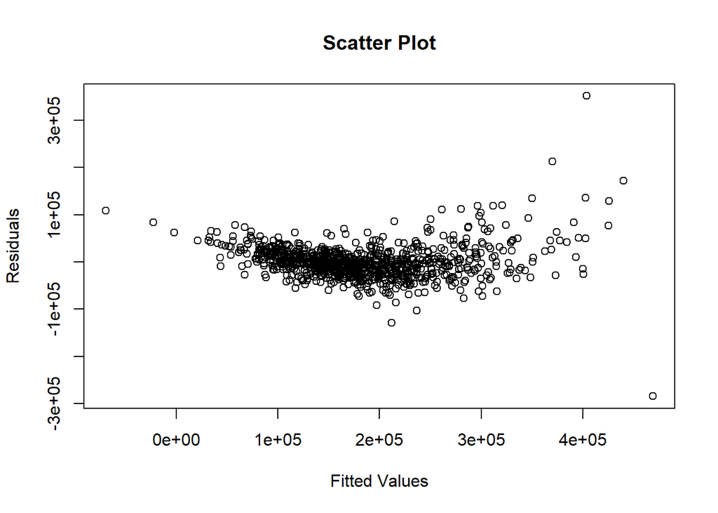

```r
plot(Model_2$fitted.values, Model_2$residuals, xlab = "Fitted Values", ylab = "Residuals", main= "Scatter Plot")
```

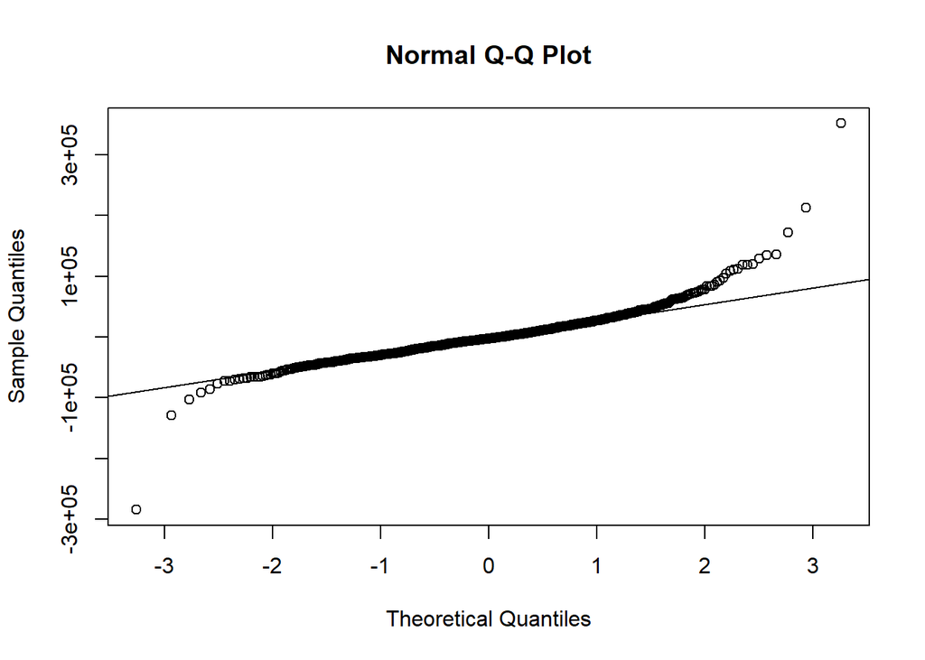

```r
qqnorm(Model_2$residuals, col= "Black")
qqline(Model_2$residuals)
```

The scatter plot reveals that the relationship between the fitted values and residuals is not entirely random; there appears to be some pattern, indicating potential issues with the model. Additionally, the quantile-quantile plot shows deviations from the expected straight line, suggesting that the residuals might not follow a normal distribution. These observations indicate that the linear regression model (Model_2) may not fully meet the assumptions. As a result, we would further explore another model called decision tree for the same dataset.

#### Decision Tree Model:-

#Running the decision tree model to perform feature selection by understanding the variable importance.

```r
Model_3 <- rpart(SalePrice ~., data = HP_train, method = 'anova', control = rpart.control(minsplit = 60))
summary(Model_3)
```

```
Call:
rpart(formula = SalePrice ~ ., data = HP_train, method = "anova",
    control = rpart.control(minsplit = 60))
  n= 900

          CP nsplit rel error    xerror       xstd
1 0.47785266      0 1.0000000 1.0009653 0.08993519
2 0.11551089      1 0.5221473 0.5257088 0.04688661
3 0.05814644      2 0.4066365 0.4107566 0.04447104
4 0.02917450      3 0.3484900 0.3649842 0.03369223
5 0.01777160      4 0.3193155 0.3402308 0.03342148
6 0.01429023      5 0.3015439 0.3326833 0.03284951
7 0.01200980      6 0.2872537 0.3261734 0.03216570
8 0.01183168      7 0.2752439 0.3174754 0.03183207
9 0.01000000      8 0.2634122 0.3082607 0.03180169

Variable importance
 OverallQual   GarageArea    YearBuilt   BsmtFinSF1 YearRemodAdd TotRmsAbvGrd
          54           14           11           10            5            3
    FullBath      LotArea BedroomAbvGr
           2            1            1

Node number 1: 900 observations,    complexity param=0.4778527
  mean=183107.9, MSE=6.701496e+09
  left son=2 (754 obs) right son=3 (146 obs)
  Primary splits:
      OverallQual  < 7.5     to the left,  improve=0.4778527, (0 missing)
      YearBuilt    < 1984.5  to the left,  improve=0.3410164, (0 missing)
      GarageArea   < 675.5   to the left,  improve=0.3352460, (0 missing)
      FullBath     < 1.5     to the left,  improve=0.2765066, (0 missing)
      YearRemodAdd < 1983.5  to the left,  improve=0.2410551, (0 missing)
  Surrogate splits:
      GarageArea   < 679     to the left,  agree=0.891, adj=0.329, (0 split)
      YearBuilt    < 2005.5  to the left,  agree=0.863, adj=0.158, (0 split)
      BsmtFinSF1   < 1336    to the left,  agree=0.860, adj=0.137, (0 split)
      YearRemodAdd < 2007.5  to the left,  agree=0.850, adj=0.075, (0 split)
      TotRmsAbvGrd < 9.5     to the left,  agree=0.844, adj=0.041, (0 split)

Node number 2: 754 observations,    complexity param=0.1155109
  mean=158206.5, MSE=2.548301e+09
```

[output cut: 114 more lines]

```

Node number 13: 22 observations
  mean=342542.1, MSE=4.645183e+09

Node number 16: 120 observations
  mean=107412.9, MSE=6.818746e+08

Node number 17: 252 observations
  mean=137263.7, MSE=7.396912e+08

Node number 18: 64 observations
  mean=138261, MSE=1.15381e+09

Node number 19: 122 observations
  mean=179491.4, MSE=1.052756e+09
```

#Predicting the price of a house based on selected predictors.

```r
Model_4 <- rpart(SalePrice ~ OverallQual + GarageArea + YearBuilt + BsmtFinSF1 + YearRemodAdd , data = HP_train, method = 'anova', control = rpart.control(minsplit = 60))
summary(Model_4)
```

```
Call:
rpart(formula = SalePrice ~ OverallQual + GarageArea + YearBuilt +
    BsmtFinSF1 + YearRemodAdd, data = HP_train, method = "anova",
    control = rpart.control(minsplit = 60))
  n= 900

          CP nsplit rel error    xerror       xstd
1 0.47785266      0 1.0000000 1.0029188 0.09011938
2 0.11551089      1 0.5221473 0.5268582 0.04714636
3 0.05814644      2 0.4066365 0.4126332 0.04473776
4 0.02755368      3 0.3484900 0.3785856 0.04146439
5 0.01777160      4 0.3209363 0.3309758 0.03335388
6 0.01429023      5 0.3031647 0.3267184 0.03310614
7 0.01124072      6 0.2888745 0.3180101 0.03253523
8 0.01000000      7 0.2776338 0.3084261 0.03255921

Variable importance
 OverallQual   GarageArea    YearBuilt   BsmtFinSF1 YearRemodAdd
          59           16           11            9            5

Node number 1: 900 observations,    complexity param=0.4778527
  mean=183107.9, MSE=6.701496e+09
  left son=2 (754 obs) right son=3 (146 obs)
  Primary splits:
      OverallQual  < 7.5    to the left,  improve=0.4778527, (0 missing)
      YearBuilt    < 1984.5 to the left,  improve=0.3410164, (0 missing)
      GarageArea   < 675.5  to the left,  improve=0.3352460, (0 missing)
      YearRemodAdd < 1983.5 to the left,  improve=0.2410551, (0 missing)
      BsmtFinSF1   < 1118.5 to the left,  improve=0.2326365, (0 missing)
  Surrogate splits:
      GarageArea   < 679    to the left,  agree=0.891, adj=0.329, (0 split)
      YearBuilt    < 2005.5 to the left,  agree=0.863, adj=0.158, (0 split)
      BsmtFinSF1   < 1336   to the left,  agree=0.860, adj=0.137, (0 split)
      YearRemodAdd < 2007.5 to the left,  agree=0.850, adj=0.075, (0 split)

Node number 2: 754 observations,    complexity param=0.1155109
  mean=158206.5, MSE=2.548301e+09
  left son=4 (558 obs) right son=5 (196 obs)
  Primary splits:
      OverallQual  < 6.5    to the left,  improve=0.3625894, (0 missing)
```

[output cut: 77 more lines]

```

Node number 11: 22 observations
  mean=268469.5, MSE=3.17058e+09

Node number 12: 82 observations
  mean=263933.7, MSE=2.741432e+09

Node number 13: 22 observations
  mean=342542.1, MSE=4.645183e+09

Node number 18: 58 observations
  mean=130751.8, MSE=9.916224e+08

Node number 19: 177 observations
  mean=170146.5, MSE=1.051203e+09
```

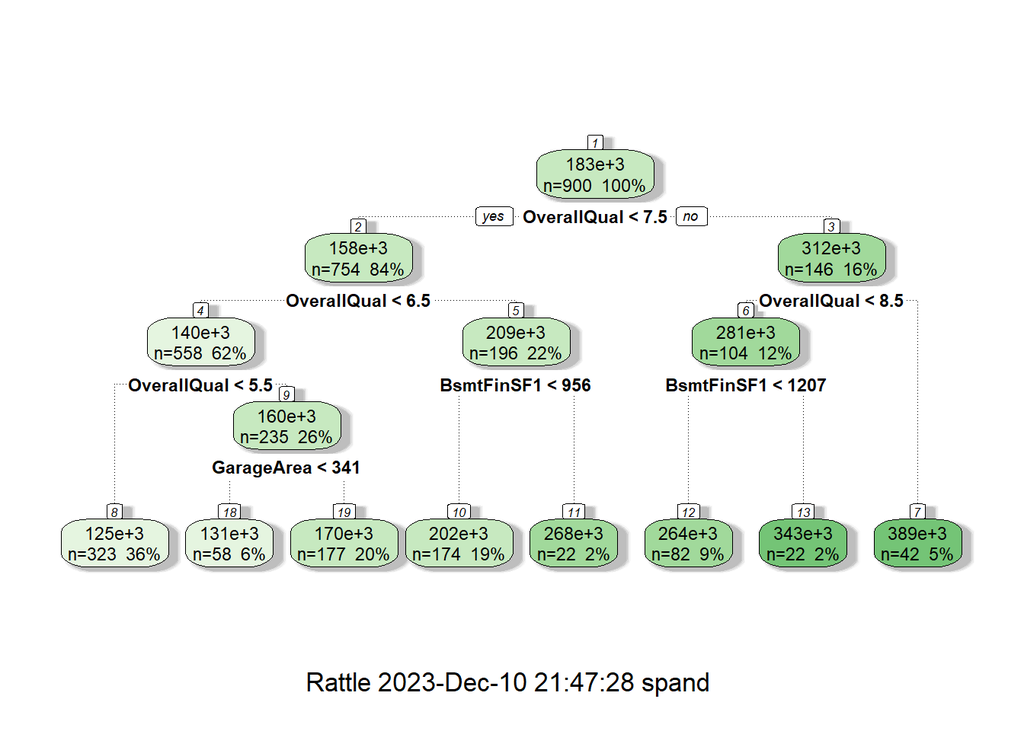

```r
fancyRpartPlot(Model_4)
```

```r
Predicted_value_2 <- predict(Model_4, data.frame(HP_test))
Predicted_value_2
```

```
       1        2        3        4        5        6        7        8
125471.0 125471.0 202038.8 202038.8 125471.0 125471.0 263933.7 202038.8
       9       10       11       12       13       14       15       16
125471.0 170146.5 125471.0 125471.0 125471.0 125471.0 170146.5 125471.0
      17       18       19       20       21       22       23       24
125471.0 125471.0 202038.8 170146.5 170146.5 125471.0 170146.5 170146.5
      25       26       27       28       29       30       31       32
170146.5 125471.0 263933.7 202038.8 263933.7 202038.8 263933.7 125471.0
      33       34       35       36       37       38       39       40
388831.3 202038.8 202038.8 125471.0 202038.8 202038.8 202038.8 202038.8
      41       42       43       44       45       46       47       48
170146.5 202038.8 125471.0 125471.0 170146.5 125471.0 125471.0 342542.1
      49       50       51       52       53       54       55       56
202038.8 170146.5 125471.0 125471.0 125471.0 125471.0 130751.8 170146.5
      57       58       59       60       61       62       63       64
170146.5 125471.0 202038.8 202038.8 125471.0 170146.5 170146.5 388831.3
      65       66       67       68       69       70       71       72
202038.8 170146.5 125471.0 125471.0 125471.0 130751.8 125471.0 202038.8
      73       74       75       76       77       78       79       80
130751.8 202038.8 202038.8 202038.8 125471.0 268469.5 125471.0 125471.0
      81       82       83       84       85       86       87       88
202038.8 263933.7 202038.8 263933.7 125471.0 125471.0 130751.8 388831.3
      89       90
170146.5 202038.8
```

The code constructs a decision tree model, to predict SalePrice using the HP_train dataset with the selected features. The model’s summary and a visual representation of the decision tree are generated. Finally, the Predicted_value_2 variable holds the predicted SalePrice values for the HP_test dataset.

#Calculating the value RMSE and Adjusted R-squared value value.

```r
Observations <- nrow(HP_train)  # number of observations
Predictors <- length(coefficients(Model_4)) - 1  # number of predictors (excluding intercept)

#Calculating R-squared Value
SSE <- sum((Predicted_value_2 - HP_train$SalePrice)^2)
SST <- sum((mean(HP_train$SalePrice) - HP_train$SalePrice)^2)
R2 <- 1 - (SSE / SST)
round(R2,3)
```

```
[1] -0.633
```

```r
# Calculating Adjusted R-squared Value
Adjusted_R2 <- 1 - (SSE / (Observations - Predictors - 1)) / (SST / (Observations - 1))
round(Adjusted_R2, 3)
```

```
[1] -0.631
```

```r
#Calculating RMSE Value
RMSE_Prediction_2 <- RMSE(Predicted_value_2, HP_test$SalePrice)
RMSE_Prediction_2
```

```
[1] 37429.64
```

#Demonstrating the Comparison between the different criteria.

```r
R_Squared_Value <- c(0.8037, -0.633)
Adjusted_R_Squared_Value <- c(0.802,-0.631)
RMSE_Value <- c(29381.9, 37429.64)

Model <- c("Linear Regression", "Decision Tree")
Model_comparision <- data.frame(Model,R_Squared_Value,Adjusted_R_Squared_Value,RMSE_Value)
pandoc.table(Model_comparision,style="grid", split.tables = Inf)
```

```
+-------------------+-----------------+--------------------------+------------+
|       Model       | R_Squared_Value | Adjusted_R_Squared_Value | RMSE_Value |
+===================+=================+==========================+============+
| Linear Regression |     0.8037      |          0.802           |   29382    |
+-------------------+-----------------+--------------------------+------------+
|   Decision Tree   |     -0.633      |          -0.631          |   37430    |
+-------------------+-----------------+--------------------------+------------+
```

#### Logistic Regression Model:-

#Converting the OverallQual variable into factor and dividing it into two levels of classes “0” and “1”.

```r
HP_train$OverallQual <- as.factor(ifelse(HP_train$OverallQual >= 7, '1', '0'))
levels(HP_train$OverallQual)
```

```
[1] "0" "1"
```

```r
HP_test$OverallQual <- as.factor(ifelse(HP_test$OverallQual >= 7, '1', '0'))
levels(HP_test$OverallQual)
```

```
[1] "0" "1"
```

#Running the logistic regression model to perform feature selection.

```r
Model_5 <- glm(OverallQual ~. , data = HP_train, family = 'binomial')
summary(Model_5)
```

```
Call:
glm(formula = OverallQual ~ ., family = "binomial", data = HP_train)

Coefficients:
               Estimate Std. Error z value Pr(>|z|)
(Intercept)   8.655e+01  1.808e+02   0.479 0.632224
LotArea      -3.361e-05  9.226e-06  -3.643 0.000269 ***
YearBuilt     1.068e-02  6.195e-03   1.724 0.084665 .
YearRemodAdd  1.773e-02  9.262e-03   1.914 0.055561 .
BsmtFinSF1   -1.910e-03  3.451e-04  -5.535 3.11e-08 ***
FullBath      3.759e-01  3.315e-01   1.134 0.256801
HalfBath     -1.261e-01  2.593e-01  -0.486 0.626724
BedroomAbvGr -6.622e-01  2.564e-01  -2.583 0.009795 **
TotRmsAbvGrd  2.109e-01  1.458e-01   1.447 0.147952
Fireplaces    1.709e-01  2.081e-01   0.821 0.411448
GarageArea    1.958e-03  1.028e-03   1.905 0.056793 .
YrSold       -7.529e-02  9.043e-02  -0.833 0.405071
SalePrice     4.298e-05  5.097e-06   8.432  < 2e-16 ***
---
Signif. codes:  0 '***' 0.001 '**' 0.01 '*' 0.05 '.' 0.1 ' ' 1

(Dispersion parameter for binomial family taken to be 1)

    Null deviance: 1195.32  on 899  degrees of freedom
Residual deviance:  471.83  on 887  degrees of freedom
AIC: 497.83

Number of Fisher Scoring iterations: 7
```

By analyzing the logistic regression model we can determine that LotArea, BsmtFinSF1, BedroomAbvGr and SalePrice are the features that have influence on the OverallQual Variable.

#Calculating the confusion matrix of the test set with that of the training set.

```r
Model_6 <- glm(OverallQual ~ LotArea + BsmtFinSF1 + BedroomAbvGr + SalePrice, data = HP_train, family = 'binomial')
summary(Model_6)
```

```
Call:
glm(formula = OverallQual ~ LotArea + BsmtFinSF1 + BedroomAbvGr +
    SalePrice, family = "binomial", data = HP_train)

Coefficients:
               Estimate Std. Error z value Pr(>|z|)
(Intercept)  -8.023e+00  7.045e-01 -11.388  < 2e-16 ***
LotArea      -4.794e-05  9.022e-06  -5.314 1.07e-07 ***
BsmtFinSF1   -2.111e-03  3.285e-04  -6.425 1.32e-10 ***
BedroomAbvGr -6.095e-01  1.751e-01  -3.481    5e-04 ***
SalePrice     5.917e-05  4.144e-06  14.280  < 2e-16 ***
---
Signif. codes:  0 '***' 0.001 '**' 0.01 '*' 0.05 '.' 0.1 ' ' 1

(Dispersion parameter for binomial family taken to be 1)

    Null deviance: 1195.32  on 899  degrees of freedom
Residual deviance:  495.31  on 895  degrees of freedom
AIC: 505.31

Number of Fisher Scoring iterations: 7
```

```r
Predicted_probs <- predict(Model_6, newdata = HP_test, type = "response")
cutoff <- 0.5
class_prediction <- ifelse(Predicted_probs > cutoff, "1", "0")
class_prediction <- as.factor(class_prediction)
HP_test$OverallQual <- as.factor(HP_test$OverallQual)
conf_matrix <- confusionMatrix(class_prediction, HP_test$OverallQual, positive = "1")
print(conf_matrix)
```

```
Confusion Matrix and Statistics

          Reference
Prediction  0  1
         0 49  8
         1  6 27

               Accuracy : 0.8444
                 95% CI : (0.7528, 0.9123)
    No Information Rate : 0.6111
    P-Value [Acc > NIR] : 1.258e-06

                  Kappa : 0.6693

 Mcnemar's Test P-Value : 0.7893

            Sensitivity : 0.7714
            Specificity : 0.8909
         Pos Pred Value : 0.8182
         Neg Pred Value : 0.8596
             Prevalence : 0.3889
         Detection Rate : 0.3000
   Detection Prevalence : 0.3667
      Balanced Accuracy : 0.8312

       'Positive' Class : 1
```

Interpretation:- The logistic regression model, applied to the categorical variable OverallQual, demonstrates its effectiveness, as evident from the confusion matrix. The accuracy of 84.44%, specificity of 89.09%, and high precision of 81.82% showcase the model’s ability to distinguish between classes. Moreover, the model generalizes well, as indicated by its strong performance on the test set. Logistic regression proves to be a robust choice for handling categorical variables and making reliable predictions.